# Palmer Penguins Walkthrough

Colton Rowe

# Abstract / Introduction

*Give some background info here, and list your driving question and main statistical methods you will use later in your project.*

Penguins are really cool animals. They have bills, flippers, and there are even different species of penguins! Question: Does bill length vary between species with statistical significance? In this project, we will use an ANOVA to test if bill lengths differ between species.

# Dataset

*Here, explain how you sourced your dataset and provide a variable-description table.*

My dataset was sourced from the library **palmerpenguins**, made avalible by Dr. Kristen Gorman and the Palmer Station.

| Variable | Description |
| --- | --- |
| Species | Species of the penguin |
| Bill Length (mm) | Bill length in millimeters |
| Flipper Length (mm) | Flipper length in millimeters |

# Visualization

*I chose to only use one plot for this mini-project, but you should include around 3 figures to identify outliers, make inferences, and more.*

*I sourced this plot from Ethan’s Palmer Penguins Visualization, found [here](https://bit.ly/dsc-gm3). Ethan goes over many different methods of visualization whichcan all be achieved in R. ggplot is a diverse library that provides many different ways to visualize your data. You could use tableu for your visualization also!*

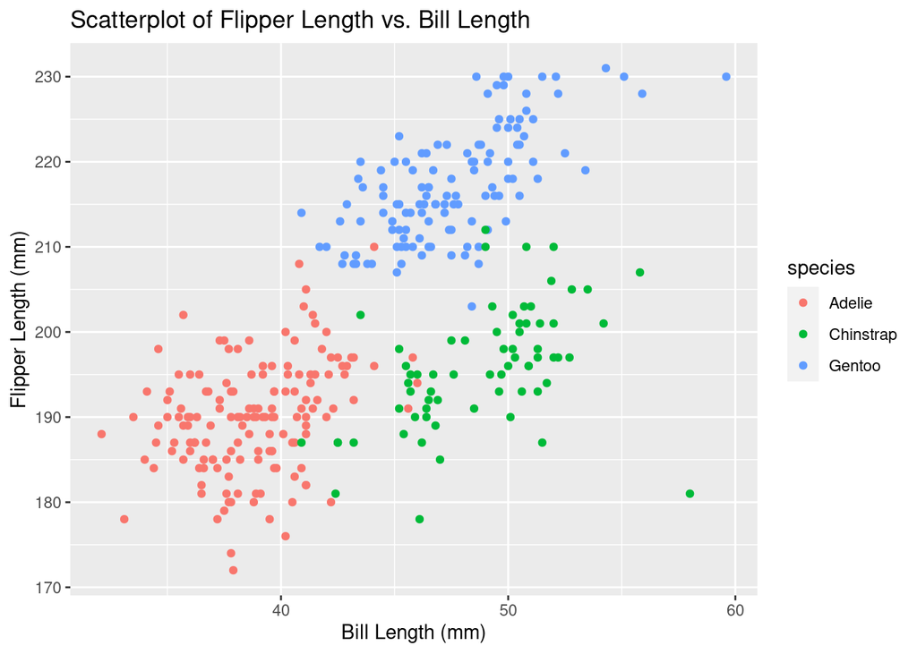

*Now, make some inferences that motivate your driving question.*

From this plot, it looks like bill length and flipper length vary between species.

# Statistical Methods

*Here, explain the statistical methods you will be using, and how they influence your driving question.*

```r
model <- lm(bill_length_mm ~ species, data=penguins)
anova_result <- anova(model)
print(anova_result)
```

```
## Analysis of Variance Table
##
## Response: bill_length_mm
##            Df Sum Sq Mean Sq F value    Pr(>F)
## species     2 7194.3  3597.2   410.6 < 2.2e-16 ***
## Residuals 339 2969.9     8.8
## ---
## Signif. codes:  0 '***' 0.001 '**' 0.01 '*' 0.05 '.' 0.1 ' ' 1
```

*Now, explain the results of your statistical methods.*

So, we have found with a p-value of 2.2e-16 that there is a statistically significant difference between the bill lengths of the penguin species. This means that it is very likely that bill length varies with species

# Conclusion